# Outlier Detection - spacialSign

## Resolve Outliers

Even under certain assumptions we can statistically define outliers, it can be hard to define in some situations. Some models are resistant to outliers (such as tree-based models and support vector machines). If a model is sensitive to outliers (like linear regression and logistic regression), we can use *spatial sign transformation* to minimize the problem. This procedure projects the predictor values onto a multidimensional sphere. This has the effect of making all the samples the same distance from the center of the sphere. (Factors are not allowed.)

> It is important to center and scale the predictor data prior to using this transformation. This does not remove outliers - it is just a preprocessing method which brings the outliers towards the majority of the data.

Once again, `caret` comes to the rescue. (I am seriously considering spending the next year just learning everything the `caret` package can do!)

First, create some data - yes, similar to the same one I have been using but with a few changes to bring out the outliers for this exercise.

```r
#Make up some data
income <- sample(seq(50000, 150000, by = 500), 95)
age <- income/2000-10
noise <- round(runif(95) * 10, 0)
age <- age + noise
income <- c(income, 10000, 15000, 300000, 250000, 230000)
age <- c(age, 30, 20, 25, 35, 95)
myData <- data.frame(income, age)
myData$education <- as.factor(sample(c("High School", "Bachelor", "Master", "Doctor"), 100, replace = TRUE, prob =c(0.7, 0.15, 0.12, 0.03) ))
```

Use `spatialSign()` in `caret` to conduct spatial sign:

```r
myTrans <- preProcess(myData[, c("income", "age")], method=c("center", "scale"))
myTransformed <- predict(myTrans, myData[, c("income", "age")])
myTransformed2 <- spatialSign(myTransformed)
myTransformed2 <- as.data.frame(myTransformed2)
head(myTransformed2, 10)
```

```
##        income        age
## 1  -0.7029692 -0.7112203
## 2  -0.5498582 -0.8352580
## 3  -0.5807168 -0.8141057
## 4   0.5542554  0.8323467
## 5  -0.6733373 -0.7393355
## 6   0.5549489  0.8318844
## 7   0.5396606  0.8418827
## 8  -0.5148900 -0.8572563
## 9   0.5444314  0.8388053
## 10 -0.9714357  0.2373030
```

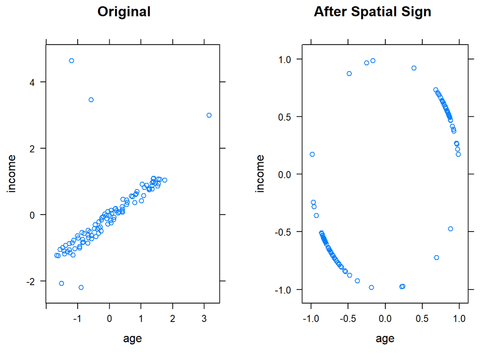

```r
p1 <- xyplot(income ~ age, data = myTransformed, main="Original")
p2 <- xyplot(income ~ age, data = myTransformed2, main="After Spatial Sign")
grid.arrange(p1, p2, ncol = 2)
```